# Statystyki

Marta Jóźwik, Ewa Baranowska

31 marca 2017

# Zadanie 3

Dla każdego zdania w podziale na kraje znajdujemy statystyki. Zobaczmy kilka przykładów:

Możemy dołożyć jeszcze informację o kontynencie. Zobaczm jak wypadają kraje jeśli chodzi o średnią czasów rozwiazywania wszytskich zadań:

```r
setwd("C:/Users/Marta/Desktop/WB_2017_1/etap 1")
load("ZRead.rda")
load("ZMat.rda")

library(dplyr)
```

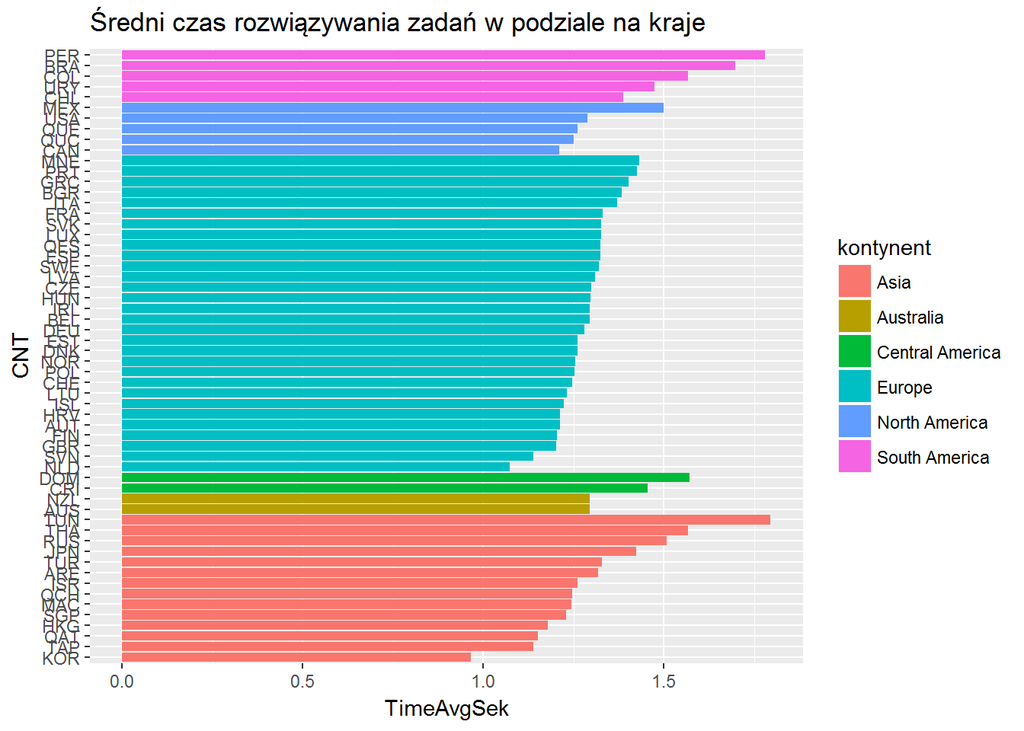

```r
library(isotone)
library(ggplot2)

################################+ taki wykres z calosci

ZRead %>% group_by(CNT,kontynent) %>% summarise(
   TimeAvgSek = weighted.mean(timing/60000, W_FSTUWT),
   TimeMedSek= weighted.median(timing/60000, W_FSTUWT)
)   %>% arrange(kontynent,TimeAvgSek)-> stat1

stat1$CNT<-reorder(stat1$CNT,1:58)
ggplot(stat1,aes(x=CNT,y=TimeAvgSek,fill=kontynent))+geom_bar(stat="identity")+coord_flip()+ggtitle("Średni czas rozwiązywania zadań w podziale na kraje")
```

```r
################################+ taki wykres mat
################################+ taki wykres science
```

Można zauważyć że średnio najkrótszy i najdłuższy czas są w Azji: Korea i Tunezja. Również od razu widać że w Ameryce Płd. wszytskie kraje mają długie średnie czasy rozwiazywania zadań.

Przedstawmy średnie czasy w podziale na poszczególne zadania i kontynenty. Dla lepszego zobrazowania wybierzmy kilka zadań, np. te zadania nad ktorymi spedzali średnio najwiecej i najmniej czasu.

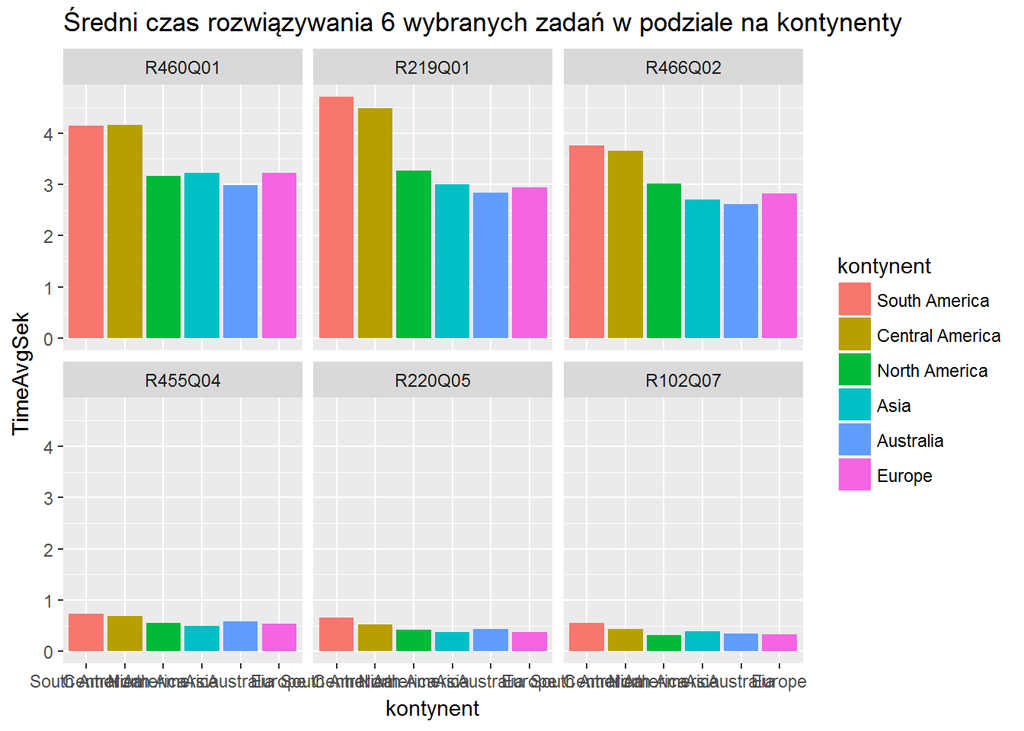

```r
#ZRead %>% group_by(item_short) %>% summarise(
#   TimeAvgSek = weighted.mean(timing/60000, W_FSTUWT)
#)   %>% arrange(TimeAvgSek)-> stat2


#wybierzmy 3 zadania z najdluzszymi i 3 z najkrotszymi srednimi czasami
zadania<-c("R102Q07","R220Q05","R455Q04","R466Q02","R219Q01","R460Q01")
zadania<-data.frame(zadania)

ZRead2<-ZRead[ZRead$item_short %in% zadania$zadania,]


ZRead2 %>% group_by(kontynent, item_short) %>% summarise(
   TimeAvgSek = weighted.mean(timing/60000, W_FSTUWT),
   TimeMedSek= weighted.median(timing/60000, W_FSTUWT)
)  %>% arrange(desc(TimeAvgSek))-> stat3

stat3$kontynent<-reorder(stat3$kontynent,1:36)
stat3$item_short<-reorder(stat3$item_short,1:36)

ggplot(stat3,aes(x=kontynent,y=TimeAvgSek,fill=kontynent))+geom_bar(stat="identity")+facet_wrap(~item_short)+ggtitle("Średni czas rozwiązywania 6 wybranych zadań w podziale na kontynenty")
```

```r
################################+ taki wykres z mat
################################+ taki wykres z science
```

Możemy zauważyć, że dla zadań z najmniejszymi średnimi czasami nie widać wielkich różnic. Natomiast patrząc na 3 ‘najdłuższe’ zadania widać, że mniej więcej utrzymuje się tendencja: najdłużej - Ameryka Płd. i Centr., najkrócej Australia, Europa i Azja zwykle podobnie.

A teraz obejrzyjmy statystyki dla najlatwiejszego (tzn takiego na ktore odsetek dobrych odpowiedzi byl najwiekszy) i najtrudniejszego pytania (analogicznie)

```r
library(sqldf)
```

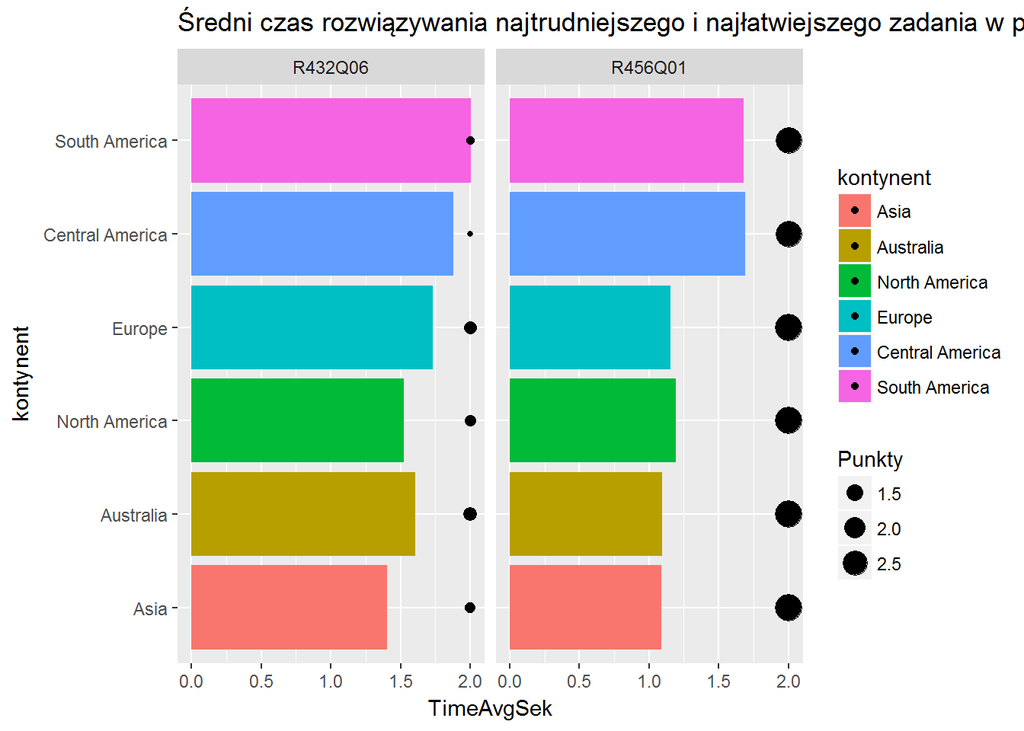

```r
#stat<-sqldf("select item_short, sum(result*W_FSTUWT)/sum(W_FSTUWT) as #mean_result
#            from ZRead group by item_short ")
#stat$mean_result<-round(stat$mean_result,4)
#sort(stat$mean_result)
#stat[stat$mean_result==2.9093,]#najlatwiejsze pytanie
#84    R456Q01      2.9093
#stat[stat$mean_result==1.1490,]#najtrudniejsze pytanie
#57    R432Q06       1.149


ZRead3<-ZRead[ZRead$item_short %in% c("R456Q01","R432Q06"),]


ZRead3 %>% group_by(kontynent, item_short) %>% summarise(
  Punkty=weighted.mean(result, W_FSTUWT),
   TimeAvgSek = weighted.mean(timing/60000, W_FSTUWT),
   TimeMedSek= weighted.median(timing/60000, W_FSTUWT)
)  %>% arrange(TimeAvgSek)-> stat4

stat4$kontynent<-reorder(stat4$kontynent,1:12)

ggplot(stat4,aes(x=kontynent,y=TimeAvgSek,fill=kontynent,))+
   geom_bar(stat="identity")+facet_wrap(~item_short)+
   coord_flip()+geom_point(aes(x=kontynent,y=2,size=Punkty))+ggtitle("Średni czas rozwiązywania najtrudniejszego i najłatwiejszego zadania w podziale na kontynenty")
```

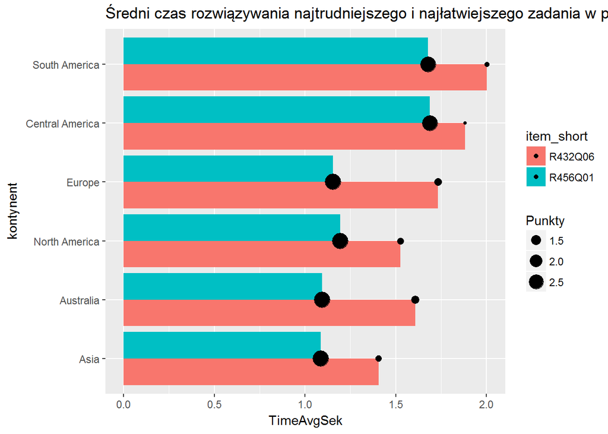

```r
ggplot(stat4,aes(x=kontynent,y=TimeAvgSek,fill=item_short))+
   geom_bar(stat="identity",position = "dodge")+coord_flip()+
   geom_point(aes(x=kontynent,y=TimeAvgSek,size=Punkty))+ggtitle("Średni czas rozwiązywania najtrudniejszego i najłatwiejszego zadania w podziale na kontynenty")
```

```r
################################+ taki wykres z mat
################################+ taki wykres z science
```

Możemy zauważyć, że znów kontynenty zachowują takie same tendencje przy obu zadaniach. Widać również, że największa zmiana między czsami rozwiązywania trudnego i łatwego zadania nastąpiła dla Europy i Australii, a najmniejsza dla Ameryki Centralnej (nadal czas jest długi)

Teraz zrobmy te wykresy dla kilku wybranych krajów

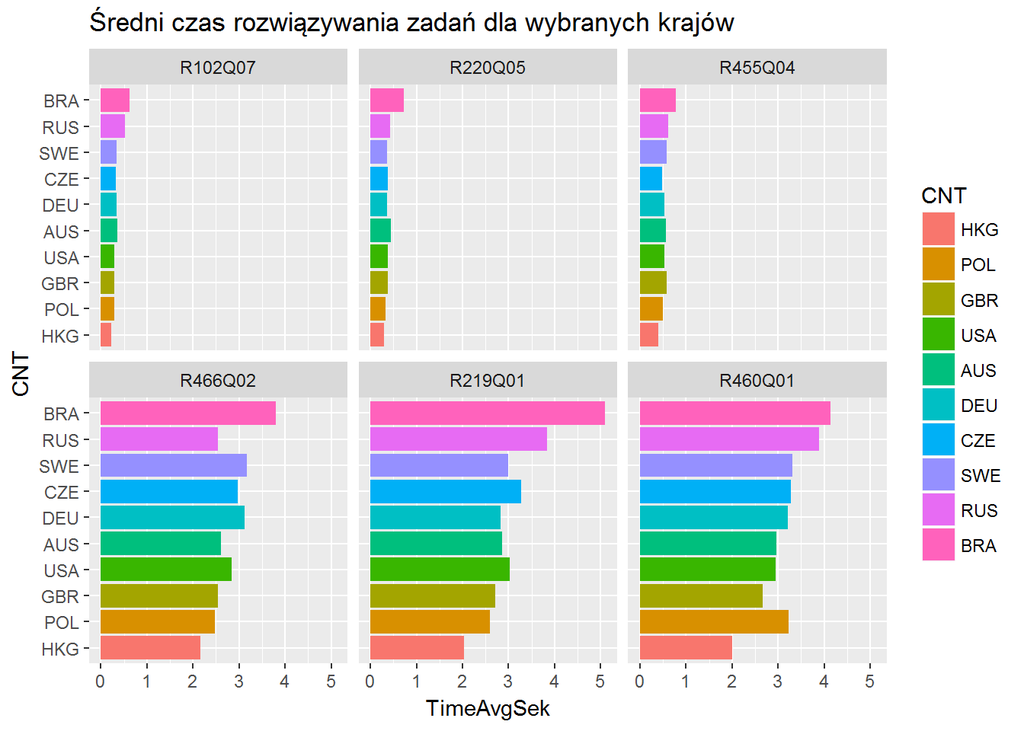

```r
################################zamiast tego dac taki wykres z calosci

kraje<-c("GBR","USA","POL","SWE","DEU","CZE","RUS","HKG","BRA","AUS")
kraje<-data.frame(kraje)
ZRead4<-ZRead2[ZRead2$CNT %in% kraje$kraje,]


ZRead4 %>% group_by(CNT, item_short) %>% summarise(
   TimeAvgSek = weighted.mean(timing/60000, W_FSTUWT),
   TimeMedSek= weighted.median(timing/60000, W_FSTUWT),
   TimeMinSek = min(timing)/60000,
   TimeMaxSek = max(timing)/60000
)  %>% arrange(TimeAvgSek)-> stat5

stat5$CNT<-reorder(stat5$CNT,1:60)
stat5$item_short<-reorder(stat5$item_short,1:60)
ggplot(stat5,aes(x=CNT,y=TimeAvgSek,fill=CNT))+geom_bar(stat="identity")+coord_flip()+facet_wrap(~item_short)+ggtitle("Średni czas rozwiązywania zadań dla wybranych krajów")
```

Można zauważyć, że ‘czołówka’ i ‘koniec stawki’ znów pozostają prawie takie same niezależnie od zadania.

Wykresy średnich czasów w podziale na płeć na kilku losowych zadaniach.

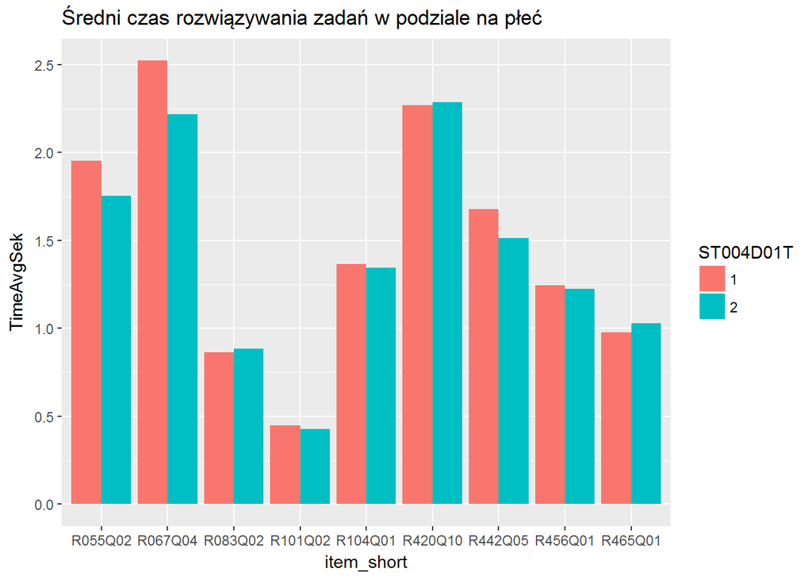

```r
ZRead %>% group_by(ST004D01T, item_short) %>% summarise(
   TimeAvgSek = weighted.mean(timing/60000, W_FSTUWT)
)  %>% arrange(item_short)-> stat6

#wykres na podstawie losowo wybranych zadan
stat6$ST004D01T<-as.factor(stat6$ST004D01T)
ggplot(stat6[c(3,4,11,12,17,18,25,26,39,40,101,102,133,134,167,168,185,186),],aes(x=item_short,y=TimeAvgSek,fill=ST004D01T))+
   geom_bar(stat="identity",position = "dodge")+ggtitle("Średni czas rozwiązywania zadań w podziale na płeć")
```

```r
################################+ taki wykres z mat
################################+ taki wykres z science
```

Wydaje się że dziewczynki? zwykle rozwiązują zadania dłużej niż chłopcy

Wykresy w podziale na poziom zdenerwowania

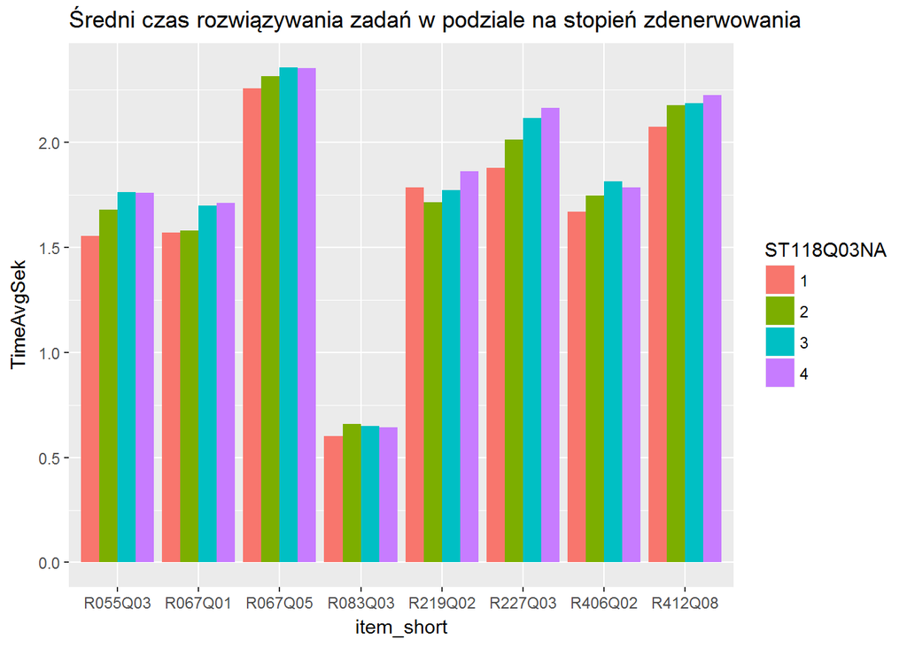

```r
#teraz w podziale na zdenerwowanie
#Even if I am well-prepared for a test I feel very anxious.
ZRead %>% group_by(ST118Q03NA, item_short) %>% summarise(
   TimeAvgSek = weighted.mean(timing/60000, W_FSTUWT)
)  %>% arrange(item_short)-> stat7

stat7$ST118Q03NA<-as.factor(stat7$ST118Q03NA)
stat7<-stat7[!is.na(stat7$ST118Q03NA),]
ggplot(stat7[c(9,10,11,12,17,18,19,20,25,26,27,28,37,38,39,40,101,102,103,104,133,134,135,136,165,166,167,168,185,186,187,188),],aes(x=item_short,y=TimeAvgSek,fill=ST118Q03NA))+
   geom_bar(stat="identity",position = "dodge")+ggtitle("Średni czas rozwiązywania zadań w podziale na stopień zdenerwowania")
```

```r
################################+ taki wykres z mat
################################+ taki wykres z science
```

wydaje się że ci którzy malo sie denerwowali rozwiązują zadania szybciej

# zadanie 3.5

Rozważymy średnie czasy rozwiązywania zadań w zależności od pozycji na której się znajdywały.

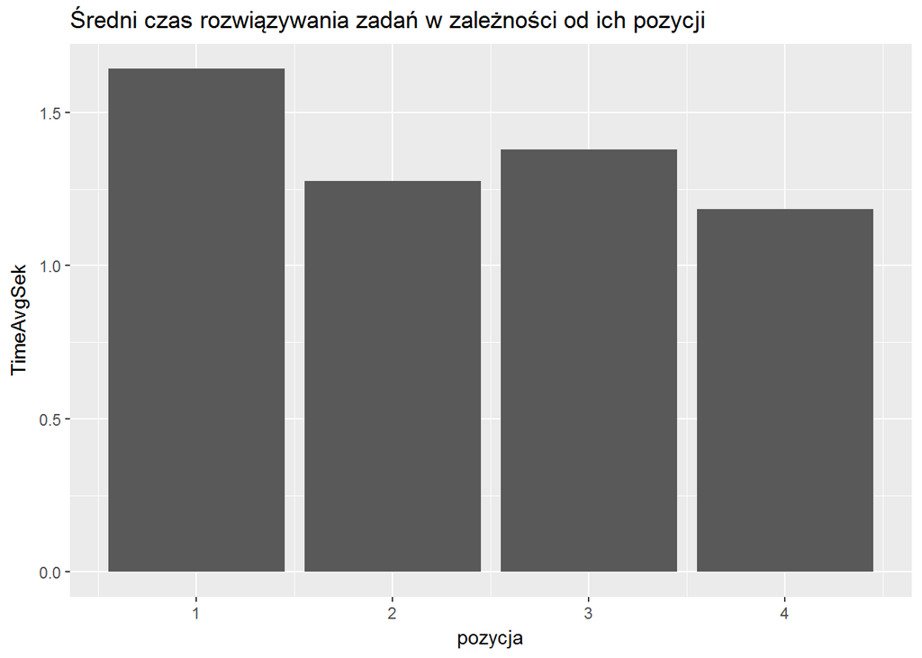

```r
################################+ taki wykres z calosci

ZRead %>% group_by(pozycja) %>% summarise(
   TimeAvgSek = weighted.mean(timing/60000, W_FSTUWT),
   TimeMedSek= weighted.median(timing/60000, W_FSTUWT)
)   %>% arrange(pozycja)-> stat8


ggplot(stat8,aes(x=pozycja,y=TimeAvgSek))+
   geom_bar(stat="identity")+ggtitle("Średni czas rozwiązywania zadań w zależności od ich pozycji")
```

```r
################################+ taki wykres z mat
################################+ taki wykres z science
```

Widać, że zadania na pozycji 1 są średnio rozwiązywane dłużej niż pozostałe, te na pozycji 4 - najkrócej.

Zobaczmy czy przy podziale na kontynenty również zachowuje się taka tendencja.

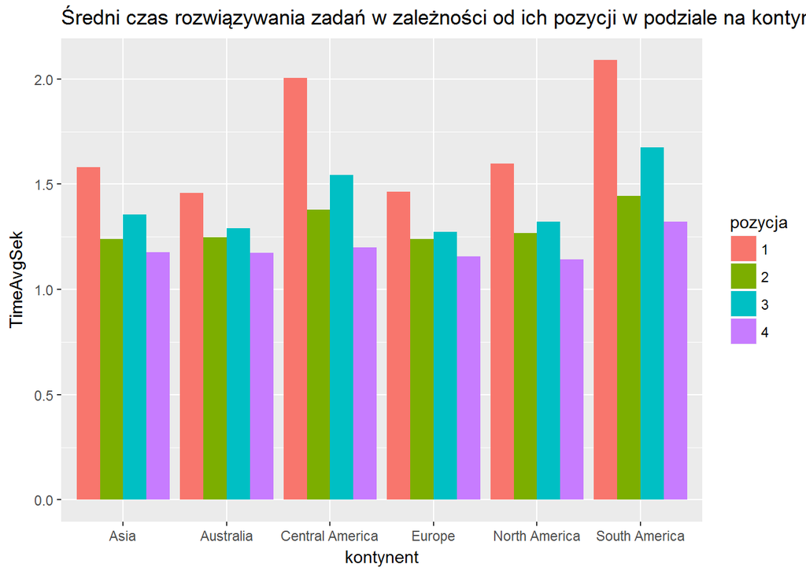

```r
################################zamiast tego? wykres z calosci

ZRead %>% group_by(pozycja,kontynent) %>% summarise(
   TimeAvgSek = weighted.mean(timing/60000, W_FSTUWT),
   TimeMedSek= weighted.median(timing/60000, W_FSTUWT)
)   %>% arrange(kontynent,pozycja)-> stat9

stat9$pozycja<-as.factor(stat9$pozycja)
ggplot(stat9,aes(x=kontynent,y=TimeAvgSek,fill=pozycja))+
   geom_bar(stat="identity",position="dodge")+
   ggtitle("Średni czas rozwiązywania zadań w zależności od ich pozycji w podziale na kontynenty")
```

Wyraźnie widać, że tendencja z poprzedniego wykresu jest zachowana

Teraz zrobmy wykresy dla wybranych krajów

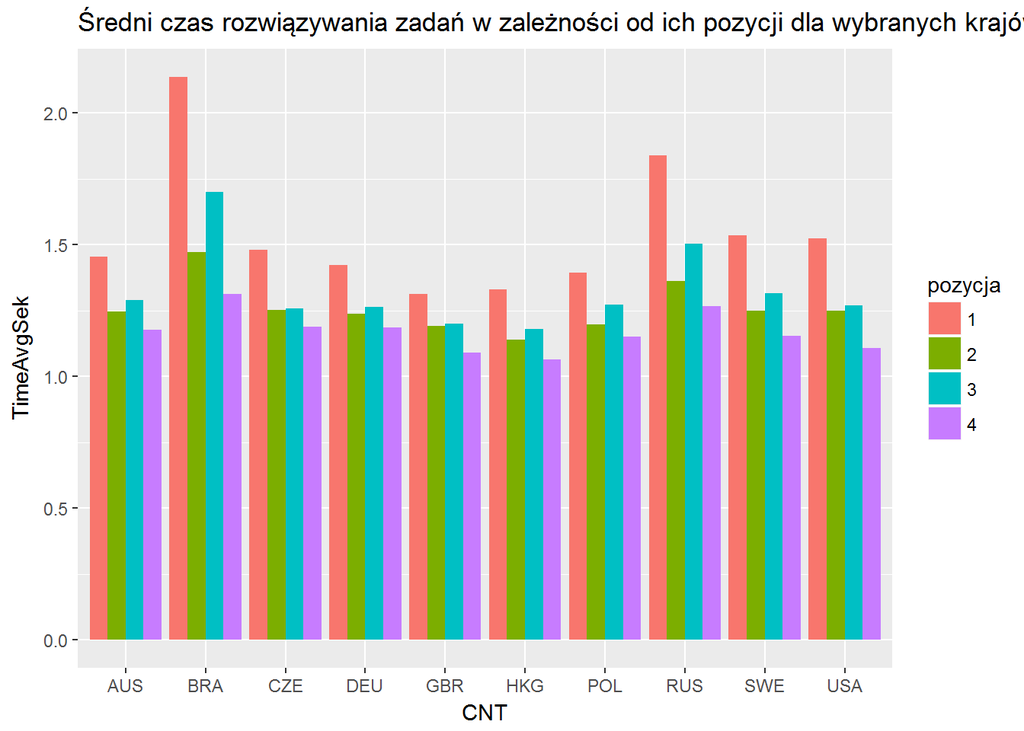

```r
################################zamiast taki wykres z calosci ew.+ z podzialem na #rodzaj zad

ZRead5<-ZRead[ZRead$CNT %in% kraje$kraje,]


ZRead5 %>% group_by(CNT, pozycja) %>% summarise(
   TimeAvgSek = weighted.mean(timing/60000, W_FSTUWT),
   TimeMedSek= weighted.median(timing/60000, W_FSTUWT)
)  %>% arrange(CNT,pozycja)-> stat10

stat10$pozycja<-as.factor(stat10$pozycja)
ggplot(stat10,aes(x=CNT,y=TimeAvgSek,fill=pozycja))+
   geom_bar(stat="identity",position="dodge")+
   ggtitle("Średni czas rozwiązywania zadań w zależności od ich pozycji dla wybranych krajów")
```

Również w podziale na poszczególne kraje tendencja jest zachowana

Zobaczmy jescze wykresy w podziale na plec i poziom zdenerwowania

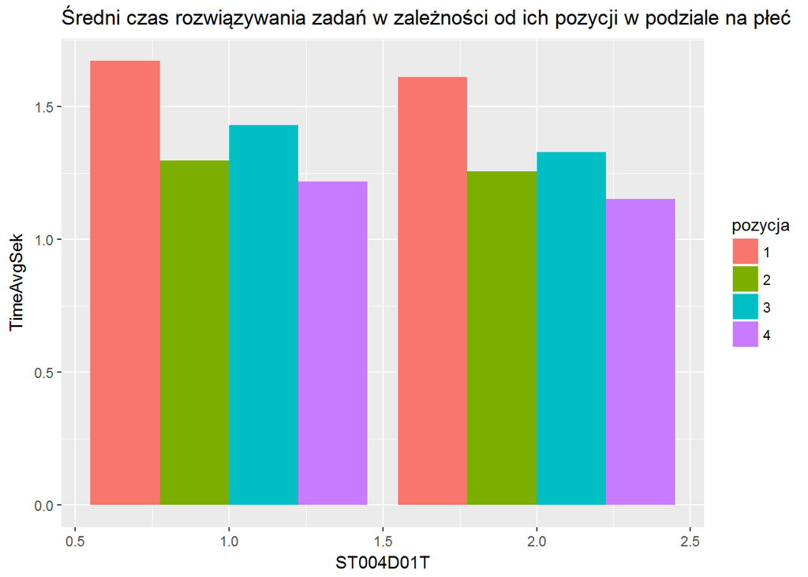

```r
################################zamiast taki wykres z calosci ew.+ z podzialem na #rodzaj zad
ZRead %>% group_by(ST004D01T, pozycja) %>% summarise(
   TimeAvgSek = weighted.mean(timing/60000, W_FSTUWT)
) -> stat11

stat11$pozycja<-as.factor(stat11$pozycja)
ggplot(stat11,aes(x=ST004D01T,y=TimeAvgSek,fill=pozycja))+
   geom_bar(stat="identity",position="dodge")+
   ggtitle("Średni czas rozwiązywania zadań w zależności od ich pozycji w podziale na płeć")
```

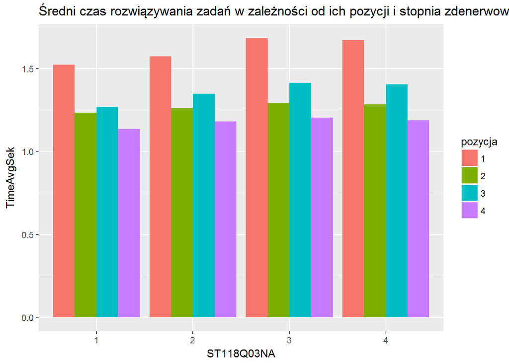

```r
#teraz w podziale na zdenerwowanie
ZRead %>% group_by(ST118Q03NA, pozycja) %>% summarise(
   TimeAvgSek = weighted.mean(timing/60000, W_FSTUWT)
) -> stat12

stat12$ST118Q03NA<-as.factor(stat12$ST118Q03NA)
stat12<-stat12[!is.na(stat12$ST118Q03NA),]
stat12$pozycja<-as.factor(stat12$pozycja)
ggplot(stat12,aes(x=ST118Q03NA,y=TimeAvgSek,fill=pozycja))+
   geom_bar(stat="identity",position="dodge")+
   ggtitle("Średni czas rozwiązywania zadań w zależności od ich pozycji i stopnia zdenerwowania")
```

Widać że dalej widzimy takie samo rozmieszczenie czsów rozwiązywania zadań: najdłużej na pozycji 1, potem szybcjie pozycja 2, następnie znów dłużej pozycja 3 i najkrócej 4.

# dorobic

przydaloby się narysować to samo dla zlepionej tabelki i zadan science i mat